# STAT2 : STATISTIQUE DESCRIPTIVE

Exo2 : Résumer une variable

Auteur·rice

Jean-Paul N’GBESSO & Claude GRASLAND

Date de publication

2025-05-27

**Télécharger l’exercice**

- [STAT2](https://github.com/worldregio/StatR/raw/refs/heads/main/exos/STAT2-univarie.zip)

## Exploration I (*var. quali.*)

### Sélection et recodage

Les variables qualitatives nominales ou *factor* sont des objets composés d’une liste de numéros et d’une liste d’étiquettes.

```r
don<-read.table(file = "data/africa_pays_2018/data/africa_pays_2018.csv",
           header=TRUE,
           sep = ";",
           dec = ",",
           encoding = "UTF-8")

# Extraction de la variable
X<-don$LANGFR
X
```

```
 [1] 0 1 1 1 0 1 1 1 1 1 1 1 0 0 0 1 0 1 0 0 1 0 0 0 0 1 1 1 0 0 0 0 1 0 1 0 0 1
[39] 0 0 0 1 1 1 0 0 0 0 0
```

```r
# Vérification du type
str(X)
```

```
 int [1:49] 0 1 1 1 0 1 1 1 1 1 ...
```

Si la variable chargée est de type *character* il faut la transformer avec `as.factor()` et repérer les niveaux disponibles avec `levels()`

```r
X<-as.factor(X)
class(X)
```

```
[1] "factor"
```

```r
levels(X)
```

```
[1] "0" "1"
```

On peut remplacer les niveaux en utilisant l’instruction `levels()`à nouveau, mais suivie d’un vecteur de charactères indiquant les changements de nom.

```r
levels(X)<-c("non francophone","francophone")

X
```

```
 [1] non francophone francophone     francophone     francophone
 [5] non francophone francophone     francophone     francophone
 [9] francophone     francophone     francophone     francophone
[13] non francophone non francophone non francophone francophone
[17] non francophone francophone     non francophone non francophone
[21] francophone     non francophone non francophone non francophone
[25] non francophone francophone     francophone     francophone
[29] non francophone non francophone non francophone non francophone
[33] francophone     non francophone francophone     non francophone
[37] non francophone francophone     non francophone non francophone
[41] non francophone francophone     francophone     francophone
[45] non francophone non francophone non francophone non francophone
[49] non francophone
Levels: non francophone francophone
```

```r
str(X)
```

```
 Factor w/ 2 levels "non francophone",..: 1 2 2 2 1 2 2 2 2 2 ...
```

On peut transformer une variable quantitative en facteur avec la fonction `cut()`

```r
summary(don$POP)
```

```
   Min. 1st Qu.  Median    Mean 3rd Qu.    Max.
   1.00    4.90   15.20   26.27   30.10  198.40
```

```r
Y<-cut(don$POP, breaks=c(0,10,30,200))
Y
```

```
 [1] (30,200] (10,30]  (10,30]  (10,30]  (0,10]   (0,10]   (10,30]  (10,30]
 [9] (30,200] (0,10]   (0,10]   (30,200] (30,200] (0,10]   (30,200] (0,10]
[17] (30,200] (10,30]  (0,10]   (0,10]   (0,10]   (30,200] (0,10]   (0,10]
[25] (0,10]   (30,200] (10,30]  (10,30]  (10,30]  (0,10]   (10,30]  (0,10]
[33] (10,30]  (30,200] (10,30]  (30,200] (10,30]  (10,30]  (0,10]   (10,30]
[41] (0,10]   (10,30]  (0,10]   (10,30]  (30,200] (30,200] (30,200] (10,30]
[49] (10,30]
Levels: (0,10] (10,30] (30,200]
```

```r
str(Y)
```

```
 Factor w/ 3 levels "(0,10]","(10,30]",..: 3 2 2 2 1 1 2 2 3 1 ...
```

On peut ensuite recoder les classes avec `levels()`

```r
levels(Y)<-c("Petit","Moyen","Grand")
Y
```

```
 [1] Grand Moyen Moyen Moyen Petit Petit Moyen Moyen Grand Petit Petit Grand
[13] Grand Petit Grand Petit Grand Moyen Petit Petit Petit Grand Petit Petit
[25] Petit Grand Moyen Moyen Moyen Petit Moyen Petit Moyen Grand Moyen Grand
[37] Moyen Moyen Petit Moyen Petit Moyen Petit Moyen Grand Grand Grand Moyen
[49] Moyen
Levels: Petit Moyen Grand
```

```r
str(Y)
```

```
 Factor w/ 3 levels "Petit","Moyen",..: 3 2 2 2 1 1 2 2 3 1 ...
```

### Table de dénombrement

Pour dénomber une variable qualitative, on utilise l’instruction `table()` qui crée un objet particulier qui n’est ni un *data.frame*, ni une *matrix*.

```r
tab<-table(X)
tab
```

```
X
non francophone     francophone
             27              22
```

```r
str(tab)
```

```
 'table' int [1:2(1d)] 27 22
 - attr(*, "dimnames")=List of 1
  ..$ X: chr [1:2] "non francophone" "francophone"
```

On peut créer des tables à 2, 3 ou 4 dimensions

```r
tab2<-table(X,Y)
tab2
```

```
                 Y
X                 Petit Moyen Grand
  non francophone    11     6    10
  francophone         6    13     3
```

```r
str(tab2)
```

```
 'table' int [1:2, 1:3] 11 6 6 13 10 3
 - attr(*, "dimnames")=List of 2
  ..$ X: chr [1:2] "non francophone" "francophone"
  ..$ Y: chr [1:3] "Petit" "Moyen" "Grand"
```

Un objet de type *table* peut être manipulé par des fonctions spéciales comme `addmargins()` quii rajoute des sommes en ligne (et en colonne si la table est de dimension 2)

```r
addmargins(tab)
```

```
X
non francophone     francophone             Sum
             27              22              49
```

```r
addmargins(tab2)
```

```
                 Y
X                 Petit Moyen Grand Sum
  non francophone    11     6    10  27
  francophone         6    13     3  22
  Sum                17    19    13  49
```

Les objets de type `table` sont souvent la source de crises de nerf de la part des étudiants qui les confondent avec des objets de type `vecteur`, `matrice` ou `data.frame`. Il existe des fonctions de conversion d’un type vers un autre mais leur emploi n’est pas très simple.

On retiendra donc dans l’immédiat que les résultats de l’instruction `table`sont des **objets transitoires** qui servent uniquement à afficher des résultats ou produire des graphiques à l’aide des instructions `plot()` ou `barplot()`.

### Graphique avec plot()

La fonction `plot()` s’applique à la plupart de objets R. Elle produit des résultats différents selon le type d’objet qu’elle a identifié. Si on l’applique à un vecteur de type factor on obtient un **diagramme en bâtons** (à ne pas confondre avec un histogramme)

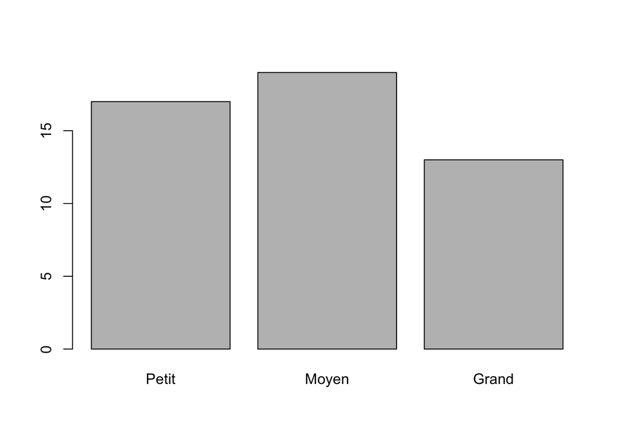

```r
plot(Y)
```

On peut améliorer le graphique en lui ajoutant des *paramètres* c’est-à-dire des instructions séparées par des virgules. Le retour à la ligne après chaque paramètre n’est pas obligatoire mais il est recommandé car il rend le code plus clair.

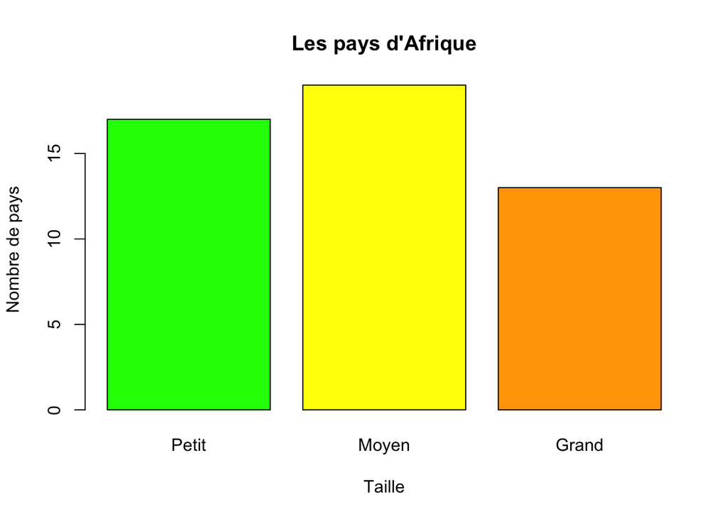

```r
plot(Y,
     col=c("green", "yellow","orange"),
     main= "Les pays d'Afrique",
     xlab = "Taille",
     ylab = "Nombre de pays")
```